# Introduction to sampling

**INM-6 Book club, 11 Oct 2019**  
**Alexandre René**

# Hands-on preparation

```
cd ~   # Or whatever directory you use for tutorials
git clone https://github.com/alcrene/sampling-tutorial.git
cd sampling-tutorial
bash ./install.sh
./START
```

# Topics

- What is sampling it good for ?
- How does it work?
  - **Typical set**
  - Markov Chain Monte Carlo
    - **Transition invariance**
  - Nested sampling
- The classic sampler: Metropolis-Hastings algorithm
- What the cool kids do: Hamiltonian Monte Carlo
  - Standard algorithm
  - Automatically tuned version (NUTS)

# Material

| *Information Theory, Inference and Learning Algorithms* (Mackay, 2003), Chaps 4, 29, 30 |  |
| --- | --- |
| *[A Conceptual Introduction to Hamiltonian Monte Carlo](https://arxiv.org/abs/1701.02434)* (Betancourt, 2017) |  |
| *[Nested sampling for general Bayesian computation](https://projecteuclid.org/euclid.ba/1340370944)* (Skilling, 2006) |  |

# What is it good for ?

[figure not shown]

- **Remark 1** It is sufficient to be able to compute $P$ up to a scaling factor. This is useful because often the normalization factor (*partition function*, or Bayesian *evidence*) is the hardest to compute.
- **Remark 2** Precisely because of Remark 1, it is not trivial to obtain the evidence from a Monte Carlo estimate.

## Monte Carlo estimate of expectations

Given a set of samples $x_i \sim P$, the expectation over $P$ can be approximated as $$\begin{aligned} Φ = \langle\phi(x)\rangle &= \int \mathrm{d}^N\!x\, P(x) \phi(x) \\ &\approx \frac{1}{N} \sum_{i=1}^N \phi(x) \end{aligned}$$

- **Remark 3** The accuracy of such a Monte Carlo estimate of depends only on the variance of $P$. In particular, it does **not depend the number of dimensions**.
- **Remark 4** Only **independent** samples count.

# How does it work

## Typicality

Consider the following distribution and function $φ$.

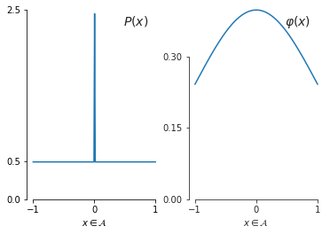

When evaluating $\int_\mathcal{A} P(x) φ(x) dx$, what matters most:

- The most likely value ($x=0$) ?
- Or the set of points $\left\{x : P(x) = 0.5\right\}$ ?

## Typicality

Another example: Consider $N$ binary random variables (spins, 0-1, coin flips, whatever) with $p_\uparrow = 1/3$ and $p_\downarrow = 2/3$.

## Typical set

Let $H$ be the average information content of a single event $\left(H = \sum_i p_i \log_2 \frac{1}{p_i}\right)$ and $N$ the number of events. The ensemble of events in the **typical set** are those whose *surprise* is within a distance $β$ of $NH$:

$$T = \left\{ x \in \mathcal{A} : \left\lvert \frac{1}{N} \log_2 \frac{1}{P(x)} - H \right\rvert < β \right\}$$

c.f. Mackay §4.4

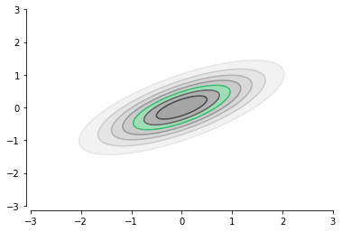

## Transition invariance (MCMC)

All MCMC samplers construct a chain of samples $x^{(1)}$, $x^{(2)}$… from a *transition probability*: $$p\left(x'\right) \sim T\left(x', x^{(t)}\right) \,.$$

Algorithms define the transition probability $T$ different, but it they must always have the following properties:

- The desired distribution $p^*(x)$ must be *invariant* under $T$:  
  $\displaystyle p^*(x') = \int d^N\!x \; T(x', x)\, p^*(x)$.
- The chain is *ergodic*:  
  $\displaystyle p^{(t)}(x) \to p^*(x)$ as $t \to \infty$, for any $p^{(0)}(x)$.

# Examples of sampling algorithms

To illustrate sampling algorithms, I will use a distribution defined as follows:

- Take $c, x \in \mathbb{R}^2$ and $f(x) = \begin{pmatrix}x_0^2 - x_1^2 \\ 2 x_0 x_1\end{pmatrix} + c \,.$
- Define $\mathcal{D}_n(s)$, $n \in 1, 2, \dotsc$ to be the distribution with the p.d.f. proportional to : $$p(c) \propto \exp\bigl[- \lVert \underbrace{f( \dotso f}_{\text{$n$ times}}(s)\dotso)\rVert_1 \bigr]$$

We set $s = \begin{pmatrix}0\\0\end{pmatrix}$ for now.

```python
with pm.Model() as known_model:
    c = cDist('c', n=2, s=(0.,0.))
```

```python
known_model
```

$$ \begin{array}{rcl} \text{c} &\sim & \mathcal{D}_{2}\left(\begin{bmatrix}0\\0\end{bmatrix}\right) \end{array} $$

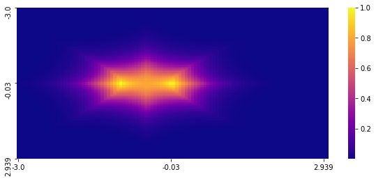

```python
ax = sns.heatmap(truedist, cmap='plasma', xticklabels=49, yticklabels=49);
```

```python
ndraws = 40000  # Use the same number of draws for all samples
```

## Metropolis-Hastings MCMC

First

1. Fix a proposal distribution $Q\left(x'; x^{(t)}\right)$ which depends on $x^{(t)}$ (usually a Gaussian).
2. Select $x^{(t)} = x^{(0)}$ (usually by sampling the prior).

Then repeat the following

1. Sample $x' \sim Q(x'; x^{(t)})$
2. Evaluate the *acceptance ratio* $\displaystyle a = \frac{p^*(x')}{p^\left(x^{(t)}\right)} \frac{Q\left(x^{(t)}, x'\right)}{Q\left(x'; x^{(t)}\right)}$.
3. If $a \geq 1$, accept the new state.  
   Otherwise, accept with probability $a$.
4. If new state is accepted, set $x^{(t+1)} = x'$  
   Otherwise, set $x^{(t+1)} = x^{(t)}$.

**Main parameters**

- Proposal distribution $Q$.
- Step size $ε$.

[figure not shown]

```python
with known_model:
    Metropolis_trace = pm.sample(draws=ndraws, chains=2,
                                 step=pm.Metropolis(S=None,
                                                    proposal_dist=None,
                                                    scaling=1.))
```

```
Multiprocess sampling (2 chains in 4 jobs)
Metropolis: [c]
The number of effective samples is smaller than 10% for some parameters.
```

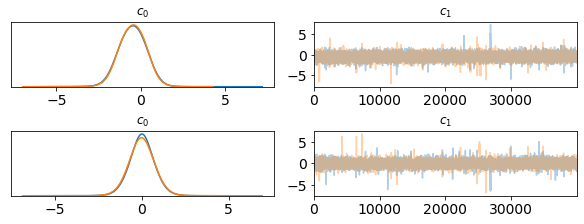

[output not shown]

[output not shown]

### Property of Metropolis-Hastings

- Steps are computationally cheap
- Computationally robust (discontinuous probabilities will not cause it to fail)
- Random-walk behaviour ⇒ need lots of samples

[figure not shown]

## Hamiltonian Monte Carlo

[figure not shown]

Requires:

- Continuous random variable
- Differentiable probability

## Hamiltonian Monte Carlo

- Augment the state space $x$ by a momentum variable $p$  
  $\displaystyle H(x,p) = E(x) + K(p)$.
- Sample from the joint density $\displaystyle P_H(x,p) = \frac{1}{Z_H} \exp\left[-H(x,p)\right] = \frac{1}{Z_H} \exp\left[-E(x)\right]\exp\left[-K(p)\right]$.
- The density is separable, so we just discard $p$ to obtain samples $\left\{x^{(t)}\right\}$ distributed according to $P(x)$.

Taken from Mackay §30.1

1. Draw a new momentum from the Gaussian density $\exp[-K(p)]/Z_K$.
2. Use a numerical integrator (usu. leap-frog) to integrate the dynamics equations for a certain number of steps. $$\begin{aligned} \dot{x} &= p \\ \dot{p} &= -\frac{\partial E(x)}{\partial x} \end{aligned}$$ The result of the integration is a proposal $(x', p')$.
3. Accept the propopsal according to the Metropolis rule.

[figure not shown]

### Why HMC works so well

- Avoids random walk behaviour;

[figure not shown]

  "Slings" samples to a far away point with the same energy
- Energy corresponds to typical set.
- In high-dimensions, the typical is a thin ring far from the mode.

[figure not shown]

```python
with known_model:
    HMC_trace = pm.sample(draws=ndraws, chains=4,
                          step=pm.HamiltonianMC(path_length=2,
                                                step_scale=0.25,
                                                scaling=None,  # Inverse mass matrix
                                                target_accept=0.65,
                                                ))
```

```
Multiprocess sampling (4 chains in 4 jobs)
HamiltonianMC: [c]
The number of effective samples is smaller than 25% for some parameters.
```

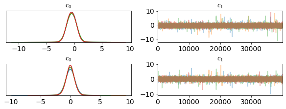

[output not shown]

[output not shown]

### Properties of HMC

- Needs differentiable probability
- Targets typical set ⇒ More efficient sampling
- Many sampling parameters to tune.  
  There may not be a unique set of parameters which works well everywhere.

## Auto-tuned Hamiltonian Monte Carlo – NUTS

"No U-Turn" sampler. Principle: integrate HMC until you are as far away as possible from the starting point.

[figure not shown]

## Auto-tuned Hamiltonian Monte Carlo – NUTS

```python
with known_model:
    NUTS_trace = pm.sample(draws=ndraws, init='jitter+adapt_diag', chains=4,
                           step=pm.NUTS())
```

```
Multiprocess sampling (4 chains in 4 jobs)
NUTS: [c]
```

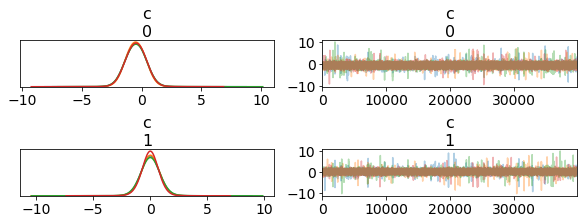

|  | effective sample size | total samples |
| --- | --- | --- |
| $c_0$ | 76200 | 160000 |
| $c_1$ | 65300 | 160000 |

[output not shown]

```python
with pm.Model() as unknown_model:
    s = pm.Normal(name='s', mu=np.array([0,0]), sd=np.array([10,10]), shape=(2,))
    c = cDist(name='c_u', n=2, s=s, observed=data)
```

$$ \begin{array}{rcl} \text{s} &\sim & \text{Normal}(\mathit{mu}=array,~\mathit{sigma}=array)\\\text{c_u} &\sim & \mathcal{D}_{2} \end{array} $$

# Dealing with gnarly distributions

What makes a distribution difficult to sample ?

- Multiple modes
- Varying curvature
- Generally, the less Gaussian-like, the harder it is

MCMC trick:

- Reparameterize to make the distribution more Gaussian like

Particle-based sampling:

- Sequential Monte Carlo
- Nested sampling – no MCMC at all (Skilling 2006)

# Exercise questions